# Mutation overview

Vegard Nygaard

10 March, 2020

A quick overview of the mutations found in the RNASeq data for the 18 human cell lines.  
The mutation calling for the RNASeq data was done using the “Finding Common Mutations In Common Cancers From RNASeq Without Germ line” workflow (homemade). This will only find a few likely driver mutations which must be previously described in the Cosmic data base.

```r
sa = read_csv("../annotation/cellline_annotation.csv")

variantclasses = c("stop_gained"="stop_gained",
                                     "stopgain"="stop_gained",
                                     "missense_variant" = "missense_variant",
                                     "nonsynonymous SNV"= "missense_variant",
                                     "nonframeshift substitution" = "missense_variant",
                                     "mutated" = "mutated",
                                     "splice_acceptor_variant" = "splice_acceptor_variant"
                                     )

# kable(sa, caption="Cell line annotation")
```

```r
nicecols = c("Sample", "Gene", "Chr", "Start", "End", "Ref", "Alt", "AN_Func.refGene", "AN_ExonicFunc.refGene", "AN_AAChange.refGene", "AN_cosmic82", "matchstring")


tabs = list()
for(cl in sa$cell_line)
{
    fn = paste0(rnaseqmutationresultdir, "/", cl, "_mutations_bigtab.csv")
    if(file.exists(fn))
    {
        tabs[[cl]] = read_csv(fn) %>%
            dplyr::select(nicecols) %>%
            dplyr::filter(AN_cosmic82 != ".") %>%
            #mutate(AAchange = getAAchange(AN_AAChange.refGene))
            tidyr::separate(AN_AAChange.refGene, into=c("tmp", "LOCUS", "exon", "NTchange", "AAchange"), sep=":|,", extra="drop", fill="right") %>%
            dplyr::select(-tmp) %>%
            rename("cell_line"=Sample)
    }else{
        warning("Did not find file ", fn)
        }
}
muttabRNA = do.call("rbind",tabs)

SNPs_in_cosmic = c("chr11_95825407_C_T")
do_not_trust_in_IGV = c("chr9_134007992_G_A")
muttabRNA = muttabRNA %>%
    dplyr::filter(!matchstring %in% SNPs_in_cosmic) %>%
    dplyr::filter(!matchstring %in% do_not_trust_in_IGV)

muttabRNA %>%
    group_by(matchstring) %>%
    summarise(count = n()) %>%
    arrange(desc(count)) %>%
    left_join(muttabRNA[, c("matchstring", "Gene", "AAchange", "AN_ExonicFunc.refGene")]) %>%
    distinct() %>%
    kable() %>%
  kable_styling()
```

| matchstring | count | Gene | AAchange | AN_ExonicFunc.refGene |
| --- | --- | --- | --- | --- |
| chr7_140453136_A_T | 8 | BRAF | p.V600E | nonsynonymous SNV |
| chr7_140453135_C_A | 3 | BRAF | p.V600V | synonymous SNV |
| chr7_140453135_CA_AT | 3 | BRAF | NA | nonframeshift substitution |
| chr13_32914859_G_A | 2 | BRCA2 | p.E2123K | nonsynonymous SNV |
| chr6_108985481_G_A | 2 | FOXO3 | p.S482N | nonsynonymous SNV |
| chr1_11186751_G_A | 1 | MTOR | p.R2152C | nonsynonymous SNV |
| chr1_115256529_T_A | 1 | NRAS | p.Q61L | nonsynonymous SNV |
| chr1_115256529_T_C | 1 | NRAS | p.Q61R | nonsynonymous SNV |
| chr1_27099397_C_T | 1 | ARID1A | p.Q1212X | stopgain |
| chr1_27101085_C_T | 1 | ARID1A | p.P1456L | nonsynonymous SNV |
| chr10_114925316_G_A | 1 | TCF7L2 | p.E384K | nonsynonymous SNV |
| chr10_89711881_A_G | 1 | PTEN | p.T167A | nonsynonymous SNV |
| chr10_89720670_G_A | 1 | PTEN | p.W274X | stopgain |
| chr11_95825374_T_C | 1 | MAML2 | p.Q607Q | synonymous SNV |
| chr12_58145431_G_A | 1 | CDK4 | p.R24C | nonsynonymous SNV |
| chr13_103519117_C_T | 1 | ERCC5 | p.R819W | nonsynonymous SNV |
| chr16_50825518_G_A | 1 | CYLD | p.E717K | nonsynonymous SNV |
| chr16_72984519_C_T | 1 | ZFHX3 | p.G108D | nonsynonymous SNV |
| chr17_7577085_C_T | 1 | TP53 | p.E153K | nonsynonymous SNV |
| chr17_7577105_G_A | 1 | TP53 | p.P146L | nonsynonymous SNV |
| chr17_7577105_GG_AA | 1 | TP53 | TP53 | nonframeshift substitution |
| chr17_7577106_G_A | 1 | TP53 | p.P146S | nonsynonymous SNV |
| chr17_7577509_C_T | 1 | TP53 | p.E126K | nonsynonymous SNV |
| chr17_7577559_G_A | 1 | TP53 | p.S109F | nonsynonymous SNV |
| chr17_7578190_T_C | 1 | TP53 | p.Y88C | nonsynonymous SNV |
| chr17_7578495_CA_AC | 1 | TP53 | TP53 | nonframeshift substitution |
| chr17_7578496_A_C | 1 | TP53 | p.L13R | nonsynonymous SNV |
| chr19_11145668_C_T | 1 | SMARCA4 | p.P1311S | nonsynonymous SNV |
| chr19_1615491_G_A | 1 | TCF3 | p.P539S | nonsynonymous SNV |
| chr2_48033789_C_T | 1 | MSH6 | p.R1204W | nonsynonymous SNV |
| chr20_50407266_G_A | 1 | SALL4 | p.R586C | nonsynonymous SNV |
| chr22_29091777_C_T | 1 | CHEK2 | p.E327K | nonsynonymous SNV |
| chr3_10183645_C_T | 1 | VHL | p.S38S | synonymous SNV |
| chr3_37067242_C_T | 1 | MLH1 | p.R144C | nonsynonymous SNV |
| chr4_106197498_C_T | 1 | TET2 | p.S1944F | nonsynonymous SNV |
| chr4_55599340_T_A | 1 | KIT | p.N822K | nonsynonymous SNV |
| chr5_1278891_G_A | 1 | TERT | p.Y717Y | synonymous SNV |
| chr5_176517623_C_T | 1 | FGFR4 | p.I108I | synonymous SNV |
| chr5_176721293_C_T | 1 | NSD1 | p.S2308S | synonymous SNV |
| chr7_128829066_A_G | 1 | SMO | p.D25G | nonsynonymous SNV |
| chr7_140453136_A_C | 1 | BRAF | p.V600G | nonsynonymous SNV |
| chr7_140453136_AC_CT | 1 | BRAF | NA | nonframeshift substitution |
| chr7_98509802_C_T | 1 | TRRAP | p.S722F | nonsynonymous SNV |
| chr7_98581822_C_T | 1 | TRRAP | p.I3018I | synonymous SNV |
| chr8_38273436_G_A | 1 | FGFR1 | p.S513S | synonymous SNV |
| chr8_38282209_G_A | 1 | FGFR1 | p.P163S | nonsynonymous SNV |
| chr8_41791255_G_A | 1 | MYST3 | p.R1495C | nonsynonymous SNV |
| chr8_90993682_C_T | 1 | NBN | p.E81K | nonsynonymous SNV |
| chr9_136913227_G_A | 1 | BRD3 | p.P355L | nonsynonymous SNV |
| chr9_21971017_G_A | 1 | CDKN2A | p.P114L | nonsynonymous SNV |
| chr9_21971120_G_A | 1 | CDKN2A | p.R80X | stopgain |
| chr9_21971120_GG_AA | 1 | CDKN2A | CDKN2A | nonframeshift substitution |
| chr9_21971121_G_A | 1 | CDKN2A | p.P94S | nonsynonymous SNV |
| chr9_21971153_C_A | 1 | CDKN2A | p.E69X | stopgain |
| chr9_21971177_C_A | 1 | CDKN2A | p.E61X | stopgain |
| chr9_21974684_G_A | 1 | CDKN2A | p.P48L | nonsynonymous SNV |

```r
MC1R_RNA = read_csv( "MC1R_germline_found_in_IGV.csv")
muttabRNA = muttabRNA %>%
    bind_rows(MC1R_RNA)
```

The above is summary of the findings, a couple of positions were found unreliable and removed. The MC1R variants were found by inspecting a few known germ line SNVs that are related to cancer using IGV. It was known from other sources that MC1R variants were present in these cell lines.  
Here are the individual mutations, also written to file.

```r
kable(muttabRNA) %>% kable_styling()
```

| cell_line | Gene | Chr | Start | End | Ref | Alt | AN_Func.refGene | AN_ExonicFunc.refGene | LOCUS | exon | NTchange | AAchange | AN_cosmic82 | matchstring |
| --- | --- | --- | --- | --- | --- | --- | --- | --- | --- | --- | --- | --- | --- | --- |
| A375 | MTOR | chr1 | 11186751 | 11186751 | G | A | exonic | nonsynonymous SNV | NM_004958 | exon46 | c.C6454T | p.R2152C | ID=COSM2119231;OCCURENCE=2(skin) | chr1_11186751_G_A |
| A375 | BRAF | chr7 | 140453136 | 140453136 | A | T | exonic | nonsynonymous SNV | NM_004333 | exon15 | c.T1799A | p.V600E | ID=COSM476;OCCURENCE=249(ovary),13(breast),12(upper_aerodigestive_tract),127(lung),1(autonomic_ganglia),3(endometrium),4769(large_intestine),8(testis),9(salivary_gland),4(stomach),91(eye),614(haematop… | chr7_140453136_A_T |
| A375 | TRRAP | chr7 | 98509802 | 98509802 | C | T | exonic | nonsynonymous SNV | NM_001244580 | exon18 | c.C2165T | p.S722F | ID=COSM107495,COSM107494;OCCURENCE=1(NS),14(skin),5(haematopoietic_and_lymphoid_tissue),1(large_intestine),1(upper_aerodigestive_tract) | chr7_98509802_C_T |
| A375 | CDKN2A | chr9 | 21971153 | 21971153 | C | A | exonic | stopgain | NM_000077 | exon2 | c.G205T | p.E69X | ID=COSM3092316,COSM3092317,COSM3092315,COSM13281;OCCURENCE=6(lung),2(upper_aerodigestive_tract),3(NS),5(pancreas),1(thyroid),1(oesophagus),3(skin) | chr9_21971153_C_A |
| A375 | CDKN2A | chr9 | 21971177 | 21971177 | C | A | exonic | stopgain | NM_000077 | exon2 | c.G181T | p.E61X | ID=COSM5608117,COSM5608118,COSM13486,COSM5608119;OCCURENCE=3(skin),2(oesophagus),3(NS),1(liver),6(upper_aerodigestive_tract) | chr9_21971177_C_A |
| FemxI | SMO | chr7 | 128829066 | 128829066 | A | G | exonic | nonsynonymous SNV | NM_005631 | exon1 | c.A74G | p.D25G | ID=COSM4951858;OCCURENCE=4(liver),1(central_nervous_system) | chr7_128829066_A_G |
| LOX | ARID1A | chr1 | 27099397 | 27099397 | C | T | exonic | stopgain | NM_006015 | exon14 | c.C3634T | p.Q1212X | ID=COSM254541;OCCURENCE=1(haematopoietic_and_lymphoid_tissue),3(urinary_tract),1(endometrium),1(breast),1(pancreas) | chr1_27099397_C_T |
| LOX | BRAF | chr7 | 140453136 | 140453136 | A | T | exonic | nonsynonymous SNV | NM_004333 | exon15 | c.T1799A | p.V600E | ID=COSM476;OCCURENCE=249(ovary),13(breast),12(upper_aerodigestive_tract),127(lung),1(autonomic_ganglia),3(endometrium),4769(large_intestine),8(testis),9(salivary_gland),4(stomach),91(eye),614(haematop… | chr7_140453136_A_T |
| MeWo | TCF7L2 | chr10 | 114925316 | 114925316 | G | A | exonic | nonsynonymous SNV | NM_001198530 | exon11 | c.G1150A | p.E384K | ID=COSM5753405,COSM5753404,COSM5753406;OCCURENCE=1(large_intestine) | chr10_114925316_G_A |
| MeWo | TP53 | chr17 | 7577509 | 7577509 | C | T | exonic | nonsynonymous SNV | NM_001126115 | exon3 | c.G376A | p.E126K | ID=COSM1172462,COSM4271777,COSM1172461,COSM1679494,COSM10988;OCCURENCE=1(ovary),5(upper_aerodigestive_tract),2(breast),3(lung),1(endometrium),8(large_intestine),6(haematopoietic_and_lymphoid_tissue),1… | chr17_7577509_C_T |
| MeWo | MSH6 | chr2 | 48033789 | 48033789 | C | T | exonic | nonsynonymous SNV | NM_001281492 | exon7 | c.C3610T | p.R1204W | ID=COSM1291512;OCCURENCE=1(haematopoietic_and_lymphoid_tissue),1(large_intestine),1(breast),1(upper_aerodigestive_tract) | chr2_48033789_C_T |
| MeWo | VHL | chr3 | 10183645 | 10183645 | C | T | exonic | synonymous SNV | NM_000551 | exon1 | c.C114T | p.S38S | ID=COSM18380;OCCURENCE=1(kidney) | chr3_10183645_C_T |
| MeWo | MLH1 | chr3 | 37067242 | 37067242 | C | T | exonic | nonsynonymous SNV | NM_001167619 | exon11 | c.C430T | p.R144C | ID=COSM1422593;OCCURENCE=1(haematopoietic_and_lymphoid_tissue),1(large_intestine),1(skin),2(NS) | chr3_37067242_C_T |
| MeWo | FGFR4 | chr5 | 176517623 | 176517623 | C | T | exonic | synonymous SNV | NM_022963 | exon2 | c.C324T | p.I108I | ID=COSM3340869,COSM3340870;OCCURENCE=1(large_intestine),2(skin),1(pancreas) | chr5_176517623_C_T |
| MeWo | NSD1 | chr5 | 176721293 | 176721293 | C | T | exonic | synonymous SNV | NM_022455 | exon23 | c.C6924T | p.S2308S | ID=COSM3341242,COSM3341243;OCCURENCE=5(skin) | chr5_176721293_C_T |
| MeWo | FGFR1 | chr8 | 38273436 | 38273436 | G | A | exonic | synonymous SNV | NM_001174066 | exon12 | c.C1539T | p.S513S | ID=COSM4367395,COSM2960432,COSM2960431,COSM2960429,COSM2960430;OCCURENCE=4(skin) | chr8_38273436_G_A |
| MeWo | FGFR1 | chr8 | 38282209 | 38282209 | G | A | exonic | nonsynonymous SNV | NM_001174066 | exon6 | c.C487T | p.P163S | ID=COSM2960521;OCCURENCE=1(skin) | chr8_38282209_G_A |
| MeWo | BRD3 | chr9 | 136913227 | 136913227 | G | A | exonic | nonsynonymous SNV | NM_007371 | exon6 | c.C1064T | p.P355L | ID=COSM1106550,COSM1106549,COSM4371950;OCCURENCE=1(endometrium) | chr9_136913227_G_A |
| MeWo | CDKN2A | chr9 | 21971120 | 21971120 | G | A | exonic | stopgain | NM_000077 | exon2 | c.C238T | p.R80X | ID=COSM1314729,COSM99935,COSM99191,COSM12475;OCCURENCE=18(haematopoietic_and_lymphoid_tissue),1(prostate),1(urinary_tract),1(endometrium),2(large_intestine),1(stomach),1(salivary_gland),9(vulva),1(kid… | chr9_21971120_G_A |
| MeWo | CDKN2A | chr9 | 21971120 | 21971121 | GG | AA | exonic | nonframeshift substitution | NM_000077 | exon2 | c.237_238TT | CDKN2A | ID=COSM13524;OCCURENCE=8(skin),1(soft_tissue),1(NS) | chr9_21971120_GG_AA |
| MeWo | CDKN2A | chr9 | 21971121 | 21971121 | G | A | exonic | nonsynonymous SNV | NM_058195 | exon2 | c.C280T | p.P94S | ID=COSM1167937,COSM1167938,COSM1167939;OCCURENCE=1(skin) | chr9_21971121_G_A |
| Skmel28 | ARID1A | chr1 | 27101085 | 27101085 | C | T | exonic | nonsynonymous SNV | NM_006015 | exon18 | c.C4367T | p.P1456L | ID=COSM1667289;OCCURENCE=1(skin),1(haematopoietic_and_lymphoid_tissue) | chr1_27101085_C_T |
| Skmel28 | PTEN | chr10 | 89711881 | 89711881 | A | G | exonic | nonsynonymous SNV | NM_000314 | exon6 | c.A499G | p.T167A | ID=COSM5052;OCCURENCE=1(central_nervous_system),5(skin),1(haematopoietic_and_lymphoid_tissue) | chr10_89711881_A_G |
| Skmel28 | CDK4 | chr12 | 58145431 | 58145431 | G | A | exonic | nonsynonymous SNV | NM_000075 | exon2 | c.C70T | p.R24C | ID=COSM1677139;OCCURENCE=1(skin),1(haematopoietic_and_lymphoid_tissue) | chr12_58145431_G_A |
| Skmel28 | TP53 | chr17 | 7578495 | 7578496 | CA | AC | exonic | nonframeshift substitution | NM_001126115 | exon1 | c.38_39GT | TP53 | ID=COSM12662;OCCURENCE=1(skin) | chr17_7578495_CA_AC |
| Skmel28 | TP53 | chr17 | 7578496 | 7578496 | A | C | exonic | nonsynonymous SNV | NM_001126115 | exon1 | c.T38G | p.L13R | ID=COSM1679517,COSM1679518,COSM45351,COSM1679516,COSM1679515,COSM1679514;OCCURENCE=1(liver),1(haematopoietic_and_lymphoid_tissue),1(salivary_gland),3(ovary),1(breast),1(lung) | chr17_7578496_A_C |
| Skmel28 | CHEK2 | chr22 | 29091777 | 29091777 | C | T | exonic | nonsynonymous SNV | NM_001349956 | exon10 | c.G979A | p.E327K | ID=COSM1682176;OCCURENCE=1(haematopoietic_and_lymphoid_tissue),1(skin) | chr22_29091777_C_T |
| Skmel28 | BRAF | chr7 | 140453136 | 140453136 | A | T | exonic | nonsynonymous SNV | NM_004333 | exon15 | c.T1799A | p.V600E | ID=COSM476;OCCURENCE=249(ovary),13(breast),12(upper_aerodigestive_tract),127(lung),1(autonomic_ganglia),3(endometrium),4769(large_intestine),8(testis),9(salivary_gland),4(stomach),91(eye),614(haematop… | chr7_140453136_A_T |
| WM115 | BRAF | chr7 | 140453135 | 140453136 | CA | AT | exonic | nonframeshift substitution | NM_004333 | exon15 | c.1799_1800AT | NA | ID=COSM477;OCCURENCE=1(haematopoietic_and_lymphoid_tissue),7(NS),2(biliary_tract),13(skin) | chr7_140453135_CA_AT |
| WM115 | BRAF | chr7 | 140453135 | 140453135 | C | A | exonic | synonymous SNV | NM_004333 | exon15 | c.G1800T | p.V600V | ID=COSM1578949;OCCURENCE=4(large_intestine) | chr7_140453135_C_A |
| WM1341 | BRAF | chr7 | 140453136 | 140453136 | A | C | exonic | nonsynonymous SNV | NM_004333 | exon15 | c.T1799G | p.V600G | ID=COSM6137;OCCURENCE=8(endometrium),1(large_intestine),1(ovary),4(skin) | chr7_140453136_A_C |
| WM1341 | BRAF | chr7 | 140453136 | 140453137 | AC | CT | exonic | nonframeshift substitution | NM_004333 | exon15 | c.1798_1799AG | NA | ID=COSM474;OCCURENCE=82(skin),1(pancreas),23(NS),2(large_intestine) | chr7_140453136_AC_CT |
| WM1341 | MYST3 | chr8 | 41791255 | 41791255 | G | A | exonic | nonsynonymous SNV | NM_006766 | exon17 | c.C4483T | p.R1495C | ID=COSM5932246;OCCURENCE=1(skin) | chr8_41791255_G_A |
| WM1366 | NRAS | chr1 | 115256529 | 115256529 | T | A | exonic | nonsynonymous SNV | NM_002524 | exon3 | c.A182T | p.Q61L | ID=COSM583;OCCURENCE=1(pancreas),6(liver),2(central_nervous_system),19(NS),1(soft_tissue),137(skin),1(meninges),11(thyroid),1(prostate),8(urinary_tract),52(haematopoietic_and_lymphoid_tissue),3(eye),1… | chr1_115256529_T_A |
| WM1366 | BRCA2 | chr13 | 32914859 | 32914859 | G | A | exonic | nonsynonymous SNV | NM_000059 | exon11 | c.G6367A | p.E2123K | ID=COSM4795757,COSM4795758;OCCURENCE=2(liver) | chr13_32914859_G_A |
| WM1366 | TP53 | chr17 | 7577085 | 7577085 | C | T | exonic | nonsynonymous SNV | NM_001126115 | exon4 | c.G457A | p.E153K | ID=COSM3717625,COSM137087,COSM10722,COSM1649345;OCCURENCE=5(skin),1(soft_tissue),8(oesophagus),1(bone),1(thyroid),2(pancreas),1(adrenal_gland),4(biliary_tract),4(central_nervous_system),2(cervix),6(li… | chr17_7577085_C_T |
| WM1366 | SALL4 | chr20 | 50407266 | 50407266 | G | A | exonic | nonsynonymous SNV | NM_020436 | exon2 | c.C1756T | p.R586C | ID=COSM270869;OCCURENCE=1(skin),1(large_intestine) | chr20_50407266_G_A |
| WM1366 | TET2 | chr4 | 106197498 | 106197498 | C | T | exonic | nonsynonymous SNV | NM_001127208 | exon11 | c.C5831T | p.S1944F | ID=COSM1426221;OCCURENCE=1(haematopoietic_and_lymphoid_tissue),1(large_intestine) | chr4_106197498_C_T |
| WM1366 | TERT | chr5 | 1278891 | 1278891 | G | A | exonic | synonymous SNV | NM_001193376 | exon6 | c.C2151T | p.Y717Y | ID=COSM6027050;OCCURENCE=2(large_intestine) | chr5_1278891_G_A |
| WM1366 | NBN | chr8 | 90993682 | 90993682 | C | T | exonic | nonsynonymous SNV | NM_002485 | exon3 | c.G241A | p.E81K | ID=COSM5757260;OCCURENCE=1(thyroid),2(large_intestine) | chr8_90993682_C_T |
| WM1366 | CDKN2A | chr9 | 21974684 | 21974684 | G | A | exonic | nonsynonymous SNV | NM_000077 | exon1 | c.C143T | p.P48L | ID=COSM12743,COSM3092327,COSM3092328;OCCURENCE=1(large_intestine),1(upper_aerodigestive_tract),1(biliary_tract),1(oesophagus),6(skin) | chr9_21974684_G_A |
| WM1382 | BRCA2 | chr13 | 32914859 | 32914859 | G | A | exonic | nonsynonymous SNV | NM_000059 | exon11 | c.G6367A | p.E2123K | ID=COSM4795757,COSM4795758;OCCURENCE=2(liver) | chr13_32914859_G_A |
| WM1382 | KIT | chr4 | 55599340 | 55599340 | T | A | exonic | nonsynonymous SNV | NM_000222 | exon17 | c.T2466A | p.N822K | ID=COSM1321;OCCURENCE=2(genital_tract),1(NS),3(skin),9(soft_tissue),14(haematopoietic_and_lymphoid_tissue),3(testis) | chr4_55599340_T_A |
| WM239 | BRAF | chr7 | 140453135 | 140453136 | CA | AT | exonic | nonframeshift substitution | NM_004333 | exon15 | c.1799_1800AT | NA | ID=COSM477;OCCURENCE=1(haematopoietic_and_lymphoid_tissue),7(NS),2(biliary_tract),13(skin) | chr7_140453135_CA_AT |
| WM239 | BRAF | chr7 | 140453135 | 140453135 | C | A | exonic | synonymous SNV | NM_004333 | exon15 | c.G1800T | p.V600V | ID=COSM1578949;OCCURENCE=4(large_intestine) | chr7_140453135_C_A |
| WM266 | CYLD | chr16 | 50825518 | 50825518 | G | A | exonic | nonsynonymous SNV | NM_001042355 | exon14 | c.G2149A | p.E717K | ID=COSM5754865,COSM5754866;OCCURENCE=1(large_intestine) | chr16_50825518_G_A |
| WM266 | ZFHX3 | chr16 | 72984519 | 72984519 | C | T | exonic | nonsynonymous SNV | NM_001164766 | exon2 | c.G323A | p.G108D | ID=COSM3276901;OCCURENCE=1(large_intestine),1(thyroid) | chr16_72984519_C_T |
| WM266 | BRAF | chr7 | 140453135 | 140453136 | CA | AT | exonic | nonframeshift substitution | NM_004333 | exon15 | c.1799_1800AT | NA | ID=COSM477;OCCURENCE=1(haematopoietic_and_lymphoid_tissue),7(NS),2(biliary_tract),13(skin) | chr7_140453135_CA_AT |
| WM266 | BRAF | chr7 | 140453135 | 140453135 | C | A | exonic | synonymous SNV | NM_004333 | exon15 | c.G1800T | p.V600V | ID=COSM1578949;OCCURENCE=4(large_intestine) | chr7_140453135_C_A |
| WM35 | BRAF | chr7 | 140453136 | 140453136 | A | T | exonic | nonsynonymous SNV | NM_004333 | exon15 | c.T1799A | p.V600E | ID=COSM476;OCCURENCE=249(ovary),13(breast),12(upper_aerodigestive_tract),127(lung),1(autonomic_ganglia),3(endometrium),4769(large_intestine),8(testis),9(salivary_gland),4(stomach),91(eye),614(haematop… | chr7_140453136_A_T |
| WM45-1 | TP53 | chr17 | 7578190 | 7578190 | T | C | exonic | nonsynonymous SNV | NM_001126115 | exon2 | c.A263G | p.Y88C | ID=COSM10758,COSM99718,COSM99720,COSM99719,COSM1644277,COSM3355993;OCCURENCE=24(central_nervous_system),12(liver),1(NS),3(biliary_tract),10(pancreas),2(bone),37(oesophagus),8(soft_tissue),2(skin),15(s… | chr17_7578190_T_C |
| WM45-1 | FOXO3 | chr6 | 108985481 | 108985481 | G | A | exonic | nonsynonymous SNV | NM_001455 | exon2 | c.G1445A | p.S482N | ID=COSM5424494;OCCURENCE=2(haematopoietic_and_lymphoid_tissue),1(thyroid) | chr6_108985481_G_A |
| WM45-1 | BRAF | chr7 | 140453136 | 140453136 | A | T | exonic | nonsynonymous SNV | NM_004333 | exon15 | c.T1799A | p.V600E | ID=COSM476;OCCURENCE=249(ovary),13(breast),12(upper_aerodigestive_tract),127(lung),1(autonomic_ganglia),3(endometrium),4769(large_intestine),8(testis),9(salivary_gland),4(stomach),91(eye),614(haematop… | chr7_140453136_A_T |
| WM793 | PTEN | chr10 | 89720670 | 89720670 | G | A | exonic | stopgain | NM_000314 | exon8 | c.G821A | p.W274X | ID=COSM5162;OCCURENCE=1(skin),1(central_nervous_system),1(endometrium),3(haematopoietic_and_lymphoid_tissue) | chr10_89720670_G_A |
| WM793 | ERCC5 | chr13 | 103519117 | 103519117 | C | T | exonic | nonsynonymous SNV | NM_000123 | exon11 | c.C2455T | p.R819W | ID=COSM945200;OCCURENCE=1(endometrium),1(large_intestine) | chr13_103519117_C_T |
| WM793 | FOXO3 | chr6 | 108985481 | 108985481 | G | A | exonic | nonsynonymous SNV | NM_001455 | exon2 | c.G1445A | p.S482N | ID=COSM5424494;OCCURENCE=2(haematopoietic_and_lymphoid_tissue),1(thyroid) | chr6_108985481_G_A |
| WM793 | BRAF | chr7 | 140453136 | 140453136 | A | T | exonic | nonsynonymous SNV | NM_004333 | exon15 | c.T1799A | p.V600E | ID=COSM476;OCCURENCE=249(ovary),13(breast),12(upper_aerodigestive_tract),127(lung),1(autonomic_ganglia),3(endometrium),4769(large_intestine),8(testis),9(salivary_gland),4(stomach),91(eye),614(haematop… | chr7_140453136_A_T |
| WM852 | NRAS | chr1 | 115256529 | 115256529 | T | C | exonic | nonsynonymous SNV | NM_002524 | exon3 | c.A182G | p.Q61R | ID=COSM584;OCCURENCE=1(kidney),13(lung),5(ovary),7(breast),5(upper_aerodigestive_tract),1(small_intestine),9(urinary_tract),10(eye),175(haematopoietic_and_lymphoid_tissue),1(stomach),3(testis),4(endom… | chr1_115256529_T_C |
| WM852 | TP53 | chr17 | 7577559 | 7577559 | G | A | exonic | nonsynonymous SNV | NM_001126115 | exon3 | c.C326T | p.S109F | ID=COSM1649402,COSM214170,COSM214172,COSM10812,COSM3522695,COSM214171;OCCURENCE=17(skin),6(oesophagus),5(pancreas),5(NS),3(biliary_tract),2(liver),8(central_nervous_system),12(ovary),11(breast),3(uppe… | chr17_7577559_G_A |
| WM9 | MAML2 | chr11 | 95825374 | 95825374 | T | C | exonic | synonymous SNV | NM_032427 | exon2 | c.A1821G | p.Q607Q | ID=COSM933635;OCCURENCE=2(thyroid),1(endometrium) | chr11_95825374_T_C |
| WM9 | SMARCA4 | chr19 | 11145668 | 11145668 | C | T | exonic | nonsynonymous SNV | NM_001128845 | exon27 | c.C3931T | p.P1311S | ID=COSM1711831,COSM1711830;OCCURENCE=2(skin) | chr19_11145668_C_T |
| WM9 | TCF3 | chr19 | 1615491 | 1615491 | G | A | exonic | nonsynonymous SNV | NM_003200 | exon18 | c.C1615T | p.P539S | ID=COSM4732695;OCCURENCE=1(large_intestine),1(NS) | chr19_1615491_G_A |
| WM9 | BRAF | chr7 | 140453136 | 140453136 | A | T | exonic | nonsynonymous SNV | NM_004333 | exon15 | c.T1799A | p.V600E | ID=COSM476;OCCURENCE=249(ovary),13(breast),12(upper_aerodigestive_tract),127(lung),1(autonomic_ganglia),3(endometrium),4769(large_intestine),8(testis),9(salivary_gland),4(stomach),91(eye),614(haematop… | chr7_140453136_A_T |
| WM9 | TRRAP | chr7 | 98581822 | 98581822 | C | T | exonic | synonymous SNV | NM_003496 | exon59 | c.C9054T | p.I3018I | ID=COSM3642827,COSM3642826;OCCURENCE=3(skin),1(large_intestine) | chr7_98581822_C_T |
| WM983 | TP53 | chr17 | 7577105 | 7577105 | G | A | exonic | nonsynonymous SNV | NM_001126115 | exon4 | c.C437T | p.P146L | ID=COSM10863,COSM129831,COSM1646812,COSM3378341;OCCURENCE=4(haematopoietic_and_lymphoid_tissue),1(prostate),11(large_intestine),2(stomach),1(salivary_gland),8(kidney),8(upper_aerodigestive_tract),8(br… | chr17_7577105_G_A |
| WM983 | TP53 | chr17 | 7577105 | 7577106 | GG | AA | exonic | nonframeshift substitution | NM_001126115 | exon4 | c.436_437TT | TP53 | ID=COSM5413391,COSM5413392,COSM43587,COSM5413390;OCCURENCE=4(skin) | chr17_7577105_GG_AA |
| WM983 | TP53 | chr17 | 7577106 | 7577106 | G | A | exonic | nonsynonymous SNV | NM_001126115 | exon4 | c.C436T | p.P146S | ID=COSM1646810,COSM10939,COSM3773297,COSM139044;OCCURENCE=3(ovary),10(breast),7(upper_aerodigestive_tract),5(lung),1(kidney),7(large_intestine),3(stomach),1(salivary_gland),2(haematopoietic_and_lympho… | chr17_7577106_G_A |
| WM983 | BRAF | chr7 | 140453136 | 140453136 | A | T | exonic | nonsynonymous SNV | NM_004333 | exon15 | c.T1799A | p.V600E | ID=COSM476;OCCURENCE=249(ovary),13(breast),12(upper_aerodigestive_tract),127(lung),1(autonomic_ganglia),3(endometrium),4769(large_intestine),8(testis),9(salivary_gland),4(stomach),91(eye),614(haematop… | chr7_140453136_A_T |
| WM983 | CDKN2A | chr9 | 21971017 | 21971017 | G | A | exonic | nonsynonymous SNV | NM_000077 | exon2 | c.C341T | p.P114L | ID=COSM753743,COSM753742,COSM3092257,COSM12476;OCCURENCE=32(skin),1(soft_tissue),3(NS),1(central_nervous_system),4(upper_aerodigestive_tract),3(lung),2(urinary_tract) | chr9_21971017_G_A |
| WM1366 | MC1R | NA | NA | NA | NA | NA | NA | nonsynonymous SNV | NA | NA | NA | R160W | NA | NA |
| WM115 | MC1R | NA | NA | NA | NA | NA | NA | nonsynonymous SNV | NA | NA | NA | R160W | NA | NA |
| A375 | MC1R | NA | NA | NA | NA | NA | NA | nonsynonymous SNV | NA | NA | NA | R151C | NA | NA |
| MeWo | MC1R | NA | NA | NA | NA | NA | NA | nonsynonymous SNV | NA | NA | NA | R160W | NA | NA |
| WM852 | MC1R | NA | NA | NA | NA | NA | NA | nonsynonymous SNV | NA | NA | NA | R160W | NA | NA |
| WM239 | MC1R | NA | NA | NA | NA | NA | NA | nonsynonymous SNV | NA | NA | NA | R160W | NA | NA |
| WM266 | MC1R | NA | NA | NA | NA | NA | NA | nonsynonymous SNV | NA | NA | NA | R160W | NA | NA |
| WM9 | MC1R | NA | NA | NA | NA | NA | NA | nonsynonymous SNV | NA | NA | NA | R151C_R160 | NA | NA |
| Skmel28 | MC1R | NA | NA | NA | NA | NA | NA | nonsynonymous SNV | NA | NA | NA | I155T | NA | NA |
| LOX | MC1R | NA | NA | NA | NA | NA | NA | nonsynonymous SNV | NA | NA | NA | R160W | NA | NA |
| FemxV | MC1R | NA | NA | NA | NA | NA | NA | nonsynonymous SNV | NA | NA | NA | R151C | NA | NA |

```r
write_tsv(muttabRNA, path=paste0(outputdir, "/mutations_from_RNASeq_", ds, ".tsv"))
```

The mutations found from RNASeq using “waterfall”-plot.

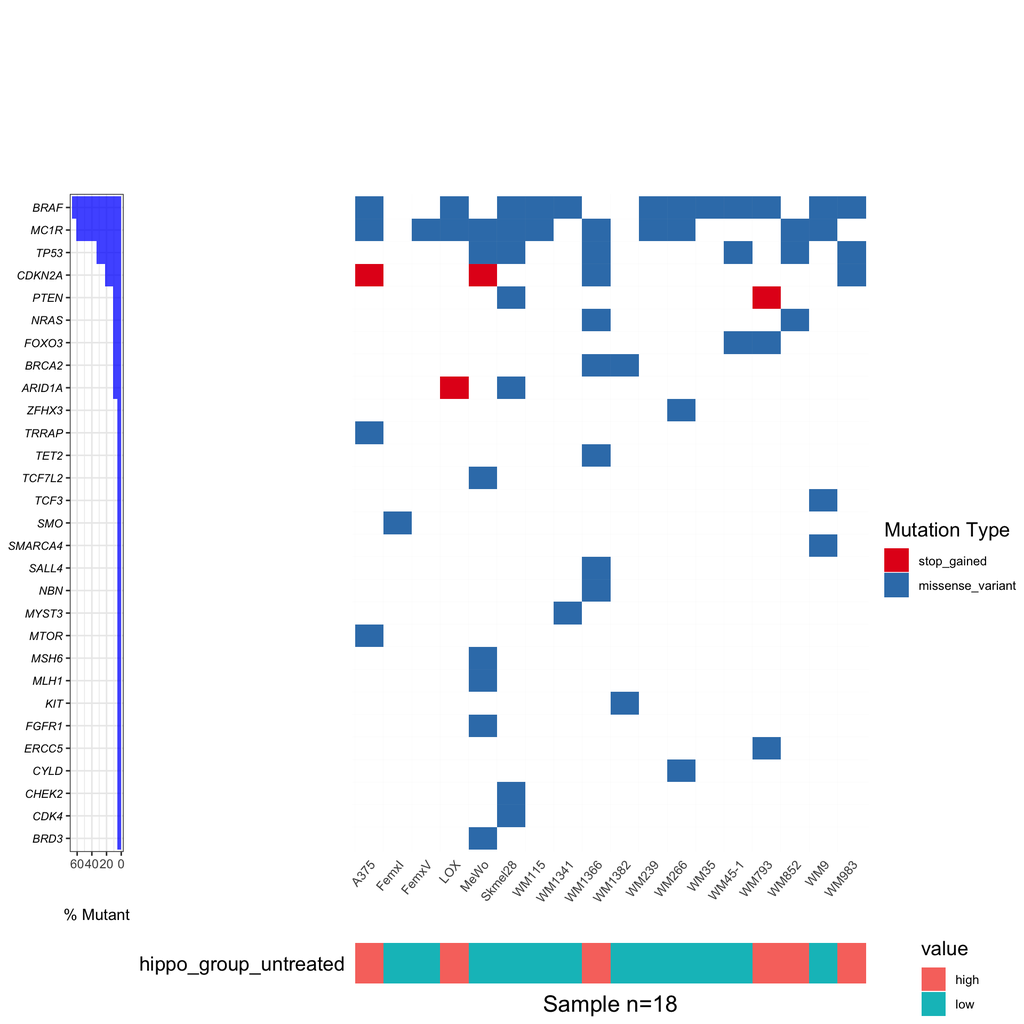

```r
muttabRNA = muttabRNA %>%
    left_join(sa)

clindata = sa %>%
    dplyr::select(cell_line, hippo_group_untreated) %>%
    rename(sample=cell_line) %>%
    gather( variable, value, -sample)

wfRNA = data.frame(sample=muttabRNA$cell_line , gene=muttabRNA$Gene, variant_class=muttabRNA$AN_ExonicFunc.refGene,
                                        mutstring=paste(muttabRNA$cell_line, muttabRNA$Gene, sep="_"), group=muttabRNA$hippo_group_untreated,
                                     stringsAsFactors = FALSE) %>%
    dplyr::filter(variant_class!="synonymous SNV" )
wfRNA$variant_class = variantclasses[wfRNA$variant_class]
#wfRNA$variant_class = factor(wfRNA$variant_class, levels=c("stopgain", "nonsynonymous SNV", "nonframeshift substitution"))
#wfRNA = wfRNA[order(wfRNA$variant_class),]

vc = unique(wfRNA$variant_class)
mp = brewer.pal(length(vc), "Set1")

#pdf(paste0(outputdir, "/waterfallplot_RNASeq_", ds, ".pdf"), width=15)
#x=waterfall(wfRNA, fileType="Custom", variant_class_order=unique(variantclasses),
#                   mainXlabel=TRUE, mainDropMut=TRUE, plotMutBurden=FALSE, plot_proportions=FALSE,
#                   sampOrder = sa$cell_line[sa$cell_line %in% wfRNA$sample], mainPalette=mp,
#                   clinData=clindata)
#x=dev.off()


x=waterfall(wfRNA, fileType="Custom", variant_class_order=unique(variantclasses),
                    mainXlabel=TRUE, mainDropMut=TRUE, plotMutBurden=FALSE, plot_proportions=FALSE,
                    sampOrder = sa$cell_line[sa$cell_line %in% wfRNA$sample], mainPalette=mp,
                    clinData=clindata)
```

```r
# rs1805005
```

Be aware that some of the only-once mutations (per gene) could be false since the workflow has relaxed settings for what is accepted (as long as it is described in Cosmic).

```r
#nonSNV = c("", "Amplified", "CN loss", "Del", "Deletion", "Normal", "WT", "WT ", "Medium", "Lacking", "Low", "Hom loss", "Hem Del", "Hem/homo Del")
#muttabhuman = sa %>%
#   dplyr::filter(cell_line != "mouse") %>%
#   left_join(read_csv("../annotation/pub_mutations.csv")) %>%
#   dplyr::select( cell_line, BRAF,PTEN, NF1, HRAS, NRAS,CDK4, MC1R, CDKN2A, TP53, MITF) %>%
#   gather(gene, state, -cell_line) %>%
#   dplyr::filter(!state %in% nonSNV) %>%
#   dplyr::filter(!is.na(state))



muttabmouse = read_csv("../annotation/mouse_mutations.csv") %>%
    dplyr::select(cell_line, symbol_human, aa_change) %>%
    rename(gene = symbol_human) %>%
    rename(state = aa_change)

mutlabs = c("Mutated", "Mut", "Del")

#muttabPUB = rbind(muttabhuman, muttabmouse) %>%
#   mutate(variant_class = "not_set") %>%
#   mutate(variant_class = if_else(state %in% mutlabs, "mutated", variant_class)) %>%
#   mutate(variant_class = if_else( grepl("\\*|x", tolower(state)), "stop_gained", variant_class)) %>%
#   mutate(variant_class = if_else(! (grepl("\\*|x", tolower(state)) | state %in% mutlabs ) , "missense_variant", variant_class))



#muttabPUB = muttabPUB %>%
#   left_join(sa)
#wfPUB = data.frame(sample=muttabPUB$cell_line , gene=muttabPUB$gene, variant_class=muttabPUB$variant_class,
#                                       group=muttabPUB$hippo_group_untreated, stringsAsFactors = FALSE)
#wfPUB$variant_class = variantclasses[wfPUB$variant_class]
#vc = unique(wfPUB$variant_class)
#mp = brewer.pal(length(vc), "Set1")
#pdf(paste0(outputdir, "/waterfallplot_publication_mutations_", ds, ".pdf"), width=15)
#x=waterfall(wfPUB, fileType="Custom",   variant_class_order=unique(variantclasses),
#                   mainXlabel=TRUE, mainDropMut=TRUE, plotMutBurden=FALSE, plot_proportions=FALSE, sampOrder = sa$cell_line[sa$cell_line %in% wfPUB$sample], mainPalette=mp)
#x=dev.off()

#x=waterfall(wfPUB, fileType="Custom",   variant_class_order=unique(variantclasses),
#                   mainXlabel=TRUE, mainDropMut=TRUE, plotMutBurden=FALSE, plot_proportions=FALSE, sampOrder = sa$cell_line[sa$cell_line %in% wfPUB$sample], mainPalette=mp)
```

The mutations found from RNASeq are limited to known cancer mutations and read depth coverage. In addition we got hold of an unpublished data set from targeted gene panel sequencing for which there was already done variant-calling. Together the two data-sets cover the most likely driver mutations, but they are not useful to assess the genome wide mutation burden due to their limited coverage.

Here are the mutations found from the gene panel.

```r
muttabDNA = read_tsv("../annotation/dna_mutations.tsv") %>%
    mutate(cell_line_dna_mut_name = CELL_LINE)
table(muttabDNA$AV_CONSTYPE)
```

```
##
##        missense_variant splice_acceptor_variant             stop_gained
##                     140                       2                       9
```

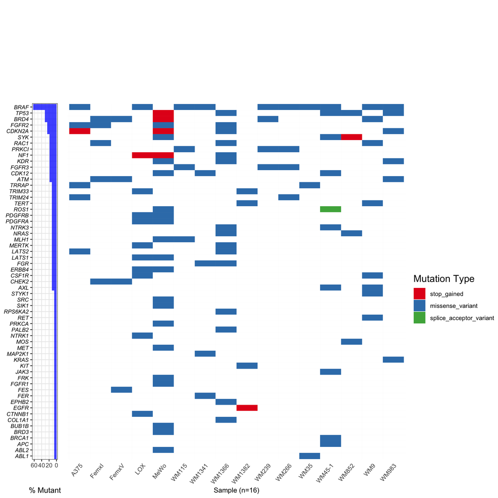

```r
wfDNA = sa %>%
    dplyr::filter(cell_line != "mouse") %>%
    inner_join(muttabDNA) %>%
    dplyr::mutate( sample=cell_line, gene=AV_GENESYM, variant_class=AV_CONSTYPE, group=hippo_group_untreated) %>%
    dplyr::select( sample, gene, variant_class, group)
#table(wfDNA$cell_line)
#wfDNA$variant_class=factor(wfDNA$variant_class, levels=c("stop_gained", "missense_variant", "splice_acceptor_variant"))


vc = unique(wfDNA$variant_class)
mp = brewer.pal(length(vc), "Set1")

#pdf(paste0(outputdir, "/waterfallplot_dna_mutations_", ds, ".pdf"), width=15, height=20)
#x=waterfall(wfDNA, fileType="Custom",   variant_class_order=unique(variantclasses),
#                   mainXlabel=TRUE, mainDropMut=TRUE, plotMutBurden=FALSE, plot_proportions=FALSE, sampOrder = sa$cell_line[sa$cell_line %in% wfDNA$sample], mainPalette=mp)
#x=dev.off()

x=waterfall(wfDNA, fileType="Custom",   variant_class_order=unique(variantclasses),
                    mainXlabel=TRUE, mainDropMut=TRUE, plotMutBurden=FALSE, plot_proportions=FALSE, sampOrder = sa$cell_line[sa$cell_line %in% wfDNA$sample], mainPalette=mp)
```

The data is also combined to make a combined plot and export lists to be used elsewhere.

```r
cols = c("sample","gene","variant_class")
wfALL = rbind( data.frame(wfDNA[,cols], foundin="DNA", stringsAsFactors=FALSE),
                             data.frame(wfRNA[,cols], foundin="RNA", stringsAsFactors=FALSE)) %>%
#                            data.frame(wfPUB[,cols], foundin="PUB", stringsAsFactors=FALSE)) %>%
    dplyr::filter(variant_class != "synonymous SNV")


wfALL$variant_class = variantclasses[wfALL$variant_class]
table(wfALL$variant_class)
```

```
##
##        missense_variant splice_acceptor_variant             stop_gained
##                     187                       1                      14
```

[figure not shown]

```r
#length(unique(wfALL$gene))
vc = unique(wfALL$variant_class)
mp = brewer.pal(length(vc), "Set1")
#pdf(paste0(outputdir, "/waterfallplot_combined_mutations_", ds, ".pdf"), width=15, height=25)
pdf(paste0(outputdir, "/fig_suppl22", ".pdf"), width=15, height=25)
x=waterfall(wfALL, fileType="Custom",   variant_class_order=unique(variantclasses),
                    mainXlabel=TRUE, mainDropMut=TRUE, plotMutBurden=FALSE, plot_proportions=FALSE, mainPalette=mp)
x=dev.off()

x=waterfall(wfALL, fileType="Custom",   variant_class_order=unique(variantclasses),
                    mainXlabel=TRUE, mainDropMut=TRUE, plotMutBurden=FALSE, plot_proportions=FALSE, mainPalette=mp)
```

```r
#wfRNADNAmouse = wfALL %>%
#   dplyr::filter( foundin!="PUB" | sample=="mouse" )

#mp = brewer.pal(length(unique(wfRNADNAmouse$variant_class)), "Set1")
#pdf(paste0(outputdir, "/waterfallplot_RNASeq_DNASeq_mutations_", ds, ".pdf"), width=15, height=25)
#x=waterfall(wfRNADNAmouse, fileType="Custom",   variant_class_order=unique(variantclasses),
#                   mainXlabel=TRUE, mainDropMut=TRUE, plotMutBurden=FALSE, plot_proportions=FALSE, mainPalette=mp)
#x=dev.off()



write_tsv(wfALL, path=paste0(outputdir, "/mutations_from_all_sources_long_format", ds, ".tsv"))


widedf = wfALL %>%
    dplyr::select(sample, gene) %>%
    distinct() %>%
    mutate(mutated = 1) %>%
    tidyr::spread(sample, mutated, fill=0)

write_tsv(widedf, path=paste0(outputdir, "/mutations_from_all_sources_wide_format", ds, ".tsv"))
```

##References

Skidmore et al. 2016 GenVisR: Genomic Visualizations in R Bioinformatics 32, 3012-3014

COSMIC  
https://cancer.sanger.ac.uk/cosmic

Bruno Zeitouni et al., Charles River  
Abstract 1840, AACR Anual Meeting April 1-5, 2017

https://www.snpedia.com/index.php/MC1R